# Анализ проблем авиаперевозок

Сафронова Анна, azsafronova

## Задача

на основе данных (и выданных вопросов) постараться выяснить:

- какие проблемы есть в авиаперевозках
- какие улучшения можно предложить на основе выводов по данным

### Вопросы

#### Вопрос 1

**Вопрос:** Правда ли оценка мест для хранения выше, если перелет был в летнее время?

**Данные:** для ответа на вопрос нужны таблицы Airline и Seat

*ШАГ №1* *Проверим гипотезу о влиянии времени года на оценку мест хранения пассажиром, рассмотрев оценки на разных категориях авиакомпаний - топовых и не топовых*

Условимся, что отзывы людей из датафрейма Airline на авиакомпанию отражают объективную картину ее крутости. Исходя из этого, составим список топовых авикакомпаний (с рейтингом >=8)

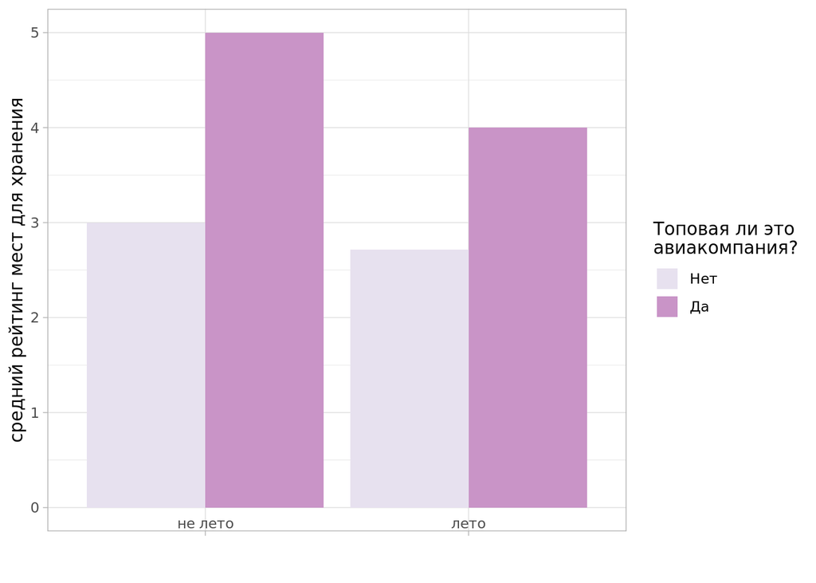

*Промежуточный вывод:* В среднем, места для хранения в топовых и не топовых авиакомпаниях летом оценивают хуже, чем в другие сезоны. Отсюда можно предположить, что, действительно, сезон коррелирует с оценкой мест так, что лучшие оценки ставят не летом. Однако, чтобы не делать преждевременных выводов, убедимся в этом, рассмотрев другую категорию.  
*ШАГ №2* *Проверим гипотезу о влиянии времени года на оценку мест хранения пассажиром, рассмотрев оценки на разных категориях типов кабин - топовых (бизнес-класс) и не топовых (эконом-класс)*

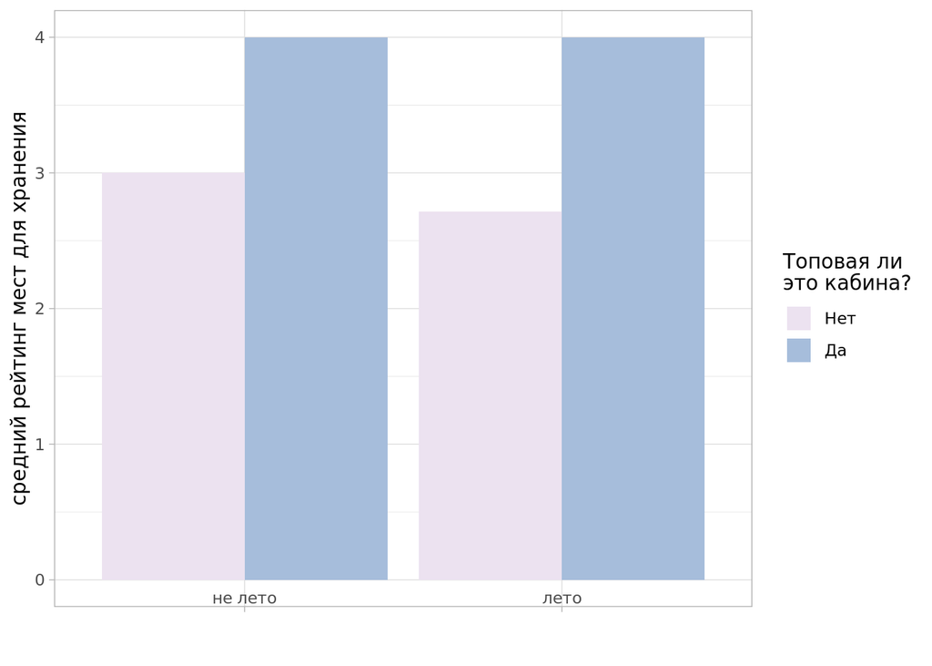

*Промежуточный вывод:* В среднем, места для хранения в не топовых кабинах летом оценивают хуже, чем в другие сезоны. В топовых же кабинах оценка не зависит от времени года.

**Ответ:** В целом, оценка мест для хранения ниже, если перелет был в летнее время.

**Вывод:** Летом часто люди летят в отпуск с детьми, а, значит, везут с собой много вещей. Все вещи довольно трудно сложить в место хранения, поэтому ощущение тесноты выливается в низкую оценку места хранения. В то же время, в бизнес-классе нет зависимости удовлетворенности местом хранения от времени года. Это может происходить либо потому, что в бизнес-классе летают люди, которые везут с собой мало вещей, либо потому, что в комфортрные отсеки для хранения в кабинах бизнес-класса с легкостью помещается все необходимое.

Чтобы оценки мест хранения летом не были ниже оценок в другие времена года, стоит расширить зону места хранения вещей в эконом-классе.

#### Вопрос 2

**Вопрос:** Пользователи каких стран чаще употребляют слово “good” (но не “not good”) в отрицательных отзывах на лаунж-зоны (то есть находят что-то хорошее, но в целом не рекомендуют)?

**Данные:** для ответа на вопрос нужна таблица Lounge

*ШАГ №1* *Создадим таблицу с названием стран и числом отзывов (а точнее, числом раз употребления в отрицательном отзыве слова “good”) ее жителей, удовлетворяющих нашей задаче. Страны без подходящих нам отзывов нас не интересуют, поэтому колонка “количество отзывов” включает только числа >=1.*

| Название страны | Количество отзывов |
| --- | --- |
| Соединённое Королевство Великобритании и Северной Ирландии | 20 |
| Австралия | 16 |
| Казахстан | 3 |
| Гонконг | 2 |
| Новая Зеландия | 2 |
| Бразилия | 1 |
| Канада | 1 |
| Китай | 1 |
| Германия | 1 |
| Норвегия | 1 |
| Филиппины | 1 |
| Португалия | 1 |
| Сингапур | 1 |
| Южная Корея | 1 |
| Швейцария | 1 |
| Соединенные Штаты Америки | 1 |

*ШАГ №2* *Для наглядности графика выберем из таблицы только страны с наибольшим количеством подходящих нам отзывов*

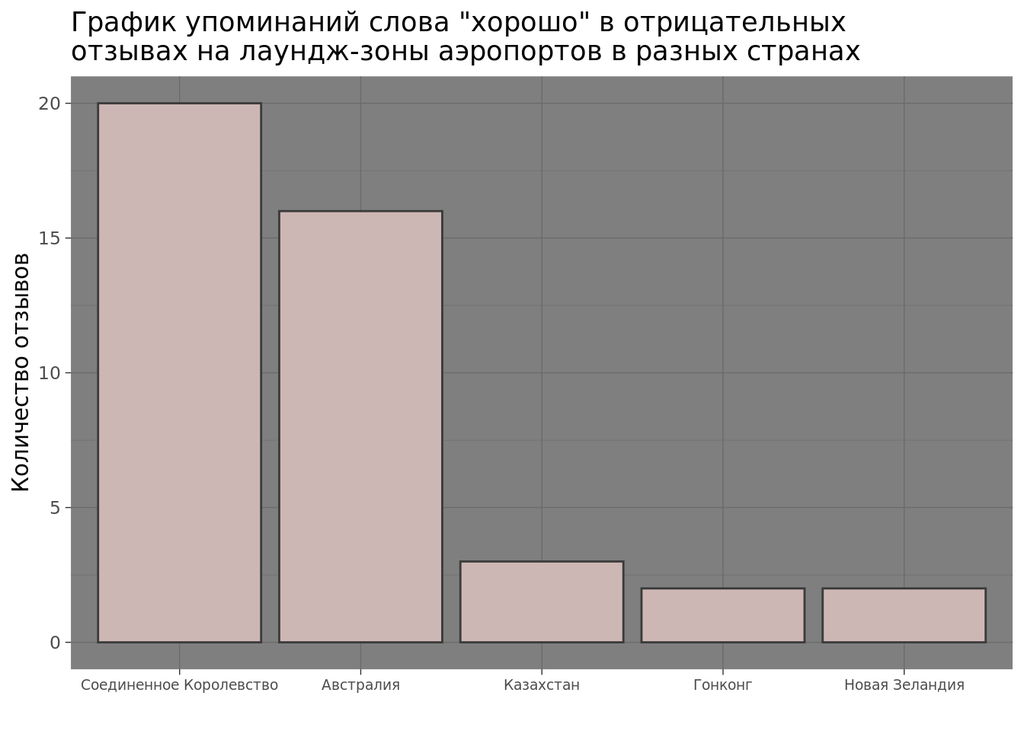

*Мы видим, что численно наибольшее число раз упоминают слово good в негативных комментариях респонденты из Соединенного Королевства, Австралии и Казахстана.*

*Однако, для более точного анализа необходимо также выявить долю комментариев со словом good в отрицательных комментариях, так как, данные о количественном превосходстве слова good могут “смазать” картину в последующем анализе.*

Например, респонденты Соединенного Королевства 20 раз написали good в отрицательных отзывах на лаундж-зоны. Но много это или мало? Если респонденты из всех остальных стран меньше раз написали слово good, это может означать либо, что они менее довольны сервисом, либо, что их отрицательных отзывов просто численно меньше.

*ШАГ №3* *Оформим данные о процентном соотношении людей, довольных чем-либо в отзывах на лаундж-зоны, и людей из этой же страны, недовольных ничем, в таблицу. При этом, укажем только страны, в которых % > 0, так как остальные не понадобятся нам в анализе.*

[output not shown]

**Вывод:** Для того, чтобы улучшить сервис, надо узнать, что конкретно заставляет людей не рекомендовать лаундж-зоны. Однако стоит учитывать, что в принятии решений об изменении сервиса, ориентироваться на отзывы абсолютно недовольных людей очень дорого - так как очень дорого переделывать весь сервис целиком. Исправление же небольших проблем, которыми немного недовольны люди из Казахстана, Германии и Австралии - быстро и дешево, так что стоит начинать именно с этого.

#### Вопрос 3

**Вопрос:** Какие лаунж-зоны оценены по чистоте выше, чем аэропорты, в которых они расположены?

**Данные:** для ответа на вопрос нужны таблицы Lounge и Airport

|  | Лаундж-зоны, рейтинг чистоты которых выше рейтинга аэропортов, в которых они находятся |
| --- | --- |
| 1 | British Airways Terraces Business Class Lounge Review |
| 2 | Etihad Airways Al Reem (Ffp Member) Lounge Review |
| 3 | Etihad Airways Business Class Lounge Customer Review |
| 4 | Etihad Airways Business Class Lounge Review |
| 5 | Royal Jordanian Airlines Business Class Lounge Review |
| 6 | Aspire Lounge 41 |
| 7 | Klm Business Class Crown Lounge Review |
| 8 | Club Atl |
| 9 | Delta Air Lines Business Class Lounge Review |
| 10 | Delta Air Lines Skyclub Business Class Lounge Review |

[output cut: 137 more lines]

*Так как в одном аэропорту есть несколько лаундж-зон, на которые могут оставить подходящий нашему условию отзыв несколько людей из одной страны, учтем это в построении столбчатой диаграммы.*

*Укажем по горизонтали название аэропорта, а по вертикали - количество отзывов, поступивших жителями рассматриваемой страны (с учетом того, что в одном аэропорту может быть несколько лаундж-зон).*

*Для наглядности покажем на графике только аэропорты с наибольшим количеством (>=23) подходящих по нашим параметрам лаундж-зон.*

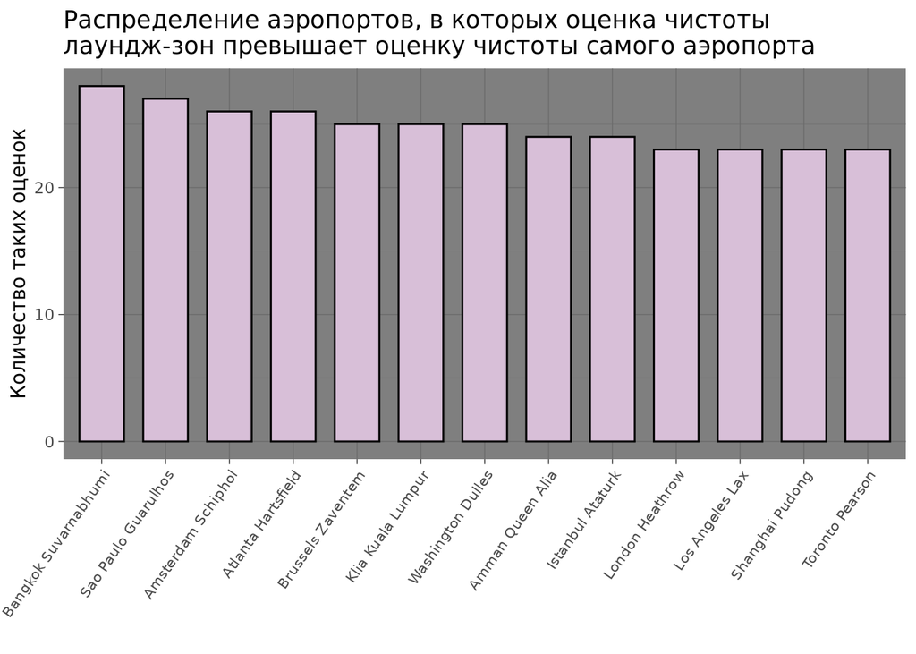

**Ответ:** Всего есть 147 лаундж-зоны, более высоко оцененных по чистоте, чем аэропорты, в которых они расположены. Среди этих лаундж-зон: British Airways Terraces Business Class Lounge Review, Etihad Airways Al Reem (Ffp Member) Lounge Review, Etihad Airways Business Class Lounge Customer Review, Etihad Airways Business Class Lounge Review, Royal Jordanian Airlines Business Class Lounge Review и другие.

**Вывод:** Bangkok Suvarnabhumi, Sao Paulo Guarulhos, Amsterdam Schiphol, Atlanta Hartsfield, Brussels Zaventem, Klia Kuala Lumpur, Washington Dulles, Amman Queen Alia, Istanbul Ataturk, London Heathrow, Los Angeles Lax, Shanghai Pudong, Toronto Pearson - 13 аэропортов, рейтинг чистоты лаундж-зон которых наибольшее количество раз, по сравнению с остальными аэропортами, был выше, чем рейтинг чистоты самих этих аэропортов.

Значит, для улучшения сервиса, именно этим тринадцати аэропортам в первую очередь нужно озаботиться наведением чистоты везде, кроме лаундж-зон (ведь ими посетители в целом довольны).

### Дэшборд

Полученные выводы обобщены в виде дэшборда со следующими элементами

**Элемент 1:**  
*вид:* График  
*ответ на вопрос:* №3  
*обоснование:* На графике очень наглядно показаны “грязные” аэропорты с наибольшим количеством “чистых” лаундж-зон. Данные можно легко и быстро интерпретировать, чтобы понять, какие аэропорты наиболее всего нуждаются в апгрейде в сфере чистоты.

**Элемент 2:**  
*вид:* Число  
*ответ на вопрос:* №3  
*обоснование:* Общее количество лаундж-зон в датафрейме помогает 4му элементу дэшборда отразить критичность ситуации в сфере чистоты аэропортов.

**Элемент 3:**  
*вид:* Таблица  
*ответ на вопрос:* №3  
*обоснование:* Таблица показывает список лаундж-зон, рейтинг чистоты которых выше рейтинга чистоты аэропортов, в которых они находятся, тем самым представляя собой не то иное, как ответ на поставленный вопрос (вопрос №3).

**Элемент 4:**  
*вид:* Число  
*ответ на вопрос:* №3  
*обоснование:* Количество лаундж-зон, представленных таблицей (3им элементом дэшбэрда), в купе с общим количеством лаундж-зон датафрейма (2ым элементом дэшборда), показывает драматичность ситуации с чистотой в представленных графиком (1м элементом дэшборда) аэропортах.

*(примечание: в дэшборде рассматривается именно третий вопрос потому, что, на мой взгляд, он наиболее практичен, и, ответив на него, можно прийти к полезным заключениям, сформулировать реальные советы по улучшению сервиса)*

### Общие выводы

В силу недостатка данных, на мой взгляд, получилось не совсем точно ответить на первый вопрос - для большей достоверности сделанных выводов стоило бы проанализировать большее число категорий.

Касаемо втрого вопроса, по моему, никаких радикально полезных выводов из него невозможно сделать. На мой взгляд, практичнее бы было узнать, в каких аэропортах чаще всего находят что-то хорошее, но в целом не рекомендуют их, чтобы проводить улучшения в конкретных аэропортах.

В третьем задании график визуализирует топ аэропортов, оценка чистоты которых ниже оценки их лаундж-зон, однако, для полного понимания, необходимо смотреть не на него, а на список, ведь в нем представлены все подходящие аэропорты.